# 015 Binary and Categorical Cross Entropy Explained

Cross-entropy is a fundamental concept in information theory that measures the difference between two probability distributions. In the context of neural networks, it's widely used as a **loss function** for classification tasks. It quantifies how much our predicted probability distribution diverges from the true distribution.

A key property of cross-entropy is that it heavily penalizes predictions that are confident but wrong. If a model predicts a high probability for the wrong class, the loss will be very large.

### Types of Cross-Entropy Loss:

There are mainly three types of cross-entropy loss used in neural networks, depending on the nature of the classification problem and how target labels are encoded:

1. **Binary Cross-Entropy (BCE) Loss:**
   - **Use Case:** Binary classification problems (e.g., spam/not-spam, cat/dog).
   - **Output Layer Activation:** Typically `sigmoid`, which outputs a single probability between 0 and 1.
   - **Target Labels:** Single value (0 or 1).
   - **Formula:** For a single sample $i$: $L\_i = -[y\_i \\log(\\hat{y}\_i) + (1 - y\_i) \\log(1 - \\hat{y}\_i)]$ where $y\_i$ is the true label (0 or 1) and $\\hat{y}\_i$ is the predicted probability of class 1. The total loss is the average over all samples.
   - **Derivative (with Sigmoid):** When combined with a sigmoid output, the derivative of BCE with respect to the pre-activation output ($Z$) simplifies beautifully to $(\\hat{y} - y)$. This makes backpropagation very stable.
2. **Categorical Cross-Entropy (CCE) Loss:**
   - **Use Case:** Multi-class classification problems where target labels are **one-hot encoded** (e.g., `[0, 0, 1]` for class 3 out of 3 classes).
   - **Output Layer Activation:** Typically `softmax`, which outputs a probability distribution over all classes.
   - **Target Labels:** One-hot encoded vectors.
   - **Formula:** For a single sample $i$ with $C$ classes: $L\_i = - \\sum\_{c=1}^{C} y\_{ic} \\log(\\hat{y}*{ic})$ where $y*{ic}$ is 1 if sample $i$ belongs to class $c$ (0 otherwise), and $\\hat{y}\_{ic}$ is the predicted probability of sample $i$ belonging to class $c$.
   - **Derivative (with Softmax):** When combined with a softmax output, the derivative of CCE with respect to the pre-activation outputs ($Z$) simplifies to $(\\hat{y} - y\_{one\_hot})$. This is also highly stable.
3. **Sparse Categorical Cross-Entropy (SCCE) Loss:**
   - **Use Case:** Multi-class classification problems where target labels are **integer-encoded** (e.g., `0, 1, 2` for class 0, 1, or 2).
   - **Output Layer Activation:** Typically `softmax`.
   - **Target Labels:** Single integer representing the class index.
   - **Relationship to CCE:** It's essentially the same mathematical loss as CCE, but it internally converts the integer labels to one-hot encoding before applying the CCE formula. This is convenient when you don't want to manually one-hot encode your labels.

```python
import numpy as np
import matplotlib.pyplot as plt
from sklearn.datasets import make_moons, make_blobs
from sklearn.model_selection import train_test_split
from sklearn.preprocessing import StandardScaler, OneHotEncoder

# --- Helper Functions (Activations, Losses, Derivatives) ---

def sigmoid(x):
    return 1 / (1 + np.exp(-np.clip(x, -500, 500))) # Clip to prevent overflow

def sigmoid_derivative(x):
    s = sigmoid(x)
    return s * (1 - s)

def relu(x):
    return np.maximum(0, x)

def relu_derivative(x):
    return np.where(x > 0, 1, 0)

def softmax(x):
    # Subtract max for numerical stability (prevents overflow for large x)
    exp_x = np.exp(x - np.max(x, axis=-1, keepdims=True))
    return exp_x / np.sum(exp_x, axis=-1, keepdims=True)

# --- Cross-Entropy Loss Functions (Manual Calculation) ---

def binary_cross_entropy_manual(y_true, y_pred):
    # Ensure y_pred is clipped to avoid log(0)
    y_pred = np.clip(y_pred, 1e-10, 1 - 1e-10)
    loss = -np.mean(y_true * np.log(y_pred) + (1 - y_true) * np.log(1 - y_pred))
    return loss

def categorical_cross_entropy_manual(y_true_one_hot, y_pred_probs):
    # Ensure y_pred_probs is clipped to avoid log(0)
    y_pred_probs = np.clip(y_pred_probs, 1e-10, 1 - 1e-10)
    # y_true_one_hot selects the log-probability of the true class
    loss = -np.mean(np.sum(y_true_one_hot * np.log(y_pred_probs), axis=1))
    return loss
```

#### Manual Calculation:

The first part of the code demonstrates the direct calculation of BCE and CCE:

- **Binary Cross-Entropy (BCE) Example:**
  - When predictions are confident and correct (e.g., `y_true=1`, `y_pred=0.99`), the loss is very small (near 0).
  - When predictions are confident but wrong (e.g., `y_true=1`, `y_pred=0.2`), the loss value is significantly higher, penalizing the model for its erroneous certainty. This is a crucial aspect of cross-entropy.
- **Categorical Cross-Entropy (CCE) Example:**
  - Similar behavior to BCE, but extended to multiple classes.
  - The loss is calculated by summing `y_true * log(y_pred_probs)` over all classes for each sample. Since `y_true` is one-hot, only the log probability of the true class contributes to the sum.
  - A high probability for the true class leads to low loss. A low probability for the true class (meaning high probabilities for incorrect classes) leads to high loss.

```python
print("--- Binary Cross-Entropy Calculation Example --- \n")

# Example 1: Binary Cross-Entropy

print("--- High confidence wrong Example --- \n")
y_true_bce = np.array([1, 0, 1, 0])
y_pred_bce = np.array([0.9, 0.1, 0.2, 0.8]) # High confidence wrong (0.2 for 1, 0.8 for 0)
bce_loss = binary_cross_entropy_manual(y_true_bce, y_pred_bce)
print(f"Binary Cross-Entropy Loss (Sample 1): {bce_loss:.4f} \n")
# Expected: High loss for (1 vs 0.2) and (0 vs 0.8)

print("--- Good predictions --- \n")
y_true_bce_perfect = np.array([1, 0, 1, 0])
y_pred_bce_perfect = np.array([0.99, 0.01, 0.98, 0.02]) # Good predictions
bce_loss_perfect = binary_cross_entropy_manual(y_true_bce_perfect, y_pred_bce_perfect)
print(f"Binary Cross-Entropy Loss (Sample 1 - Perfect): {bce_loss_perfect:.4f}")
```

```
--- Binary Cross-Entropy Calculation Example ---

--- High confidence wrong Example ---

Binary Cross-Entropy Loss (Sample 1): 0.8574

--- Good predictions ---

Binary Cross-Entropy Loss (Sample 1 - Perfect): 0.0151
```

```python
print("--- Categorical Cross-Entropy Calculation Example ---")

# Example 2: Categorical Cross-Entropy
y_true_cce_one_hot = np.array([
    [0, 1, 0], # Sample 1 is Class 2
    [1, 0, 0], # Sample 2 is Class 1
    [0, 0, 1]  # Sample 3 is Class 3
])
y_pred_cce_probs = np.array([
    [0.1, 0.8, 0.1], # Sample 1: Predict Class 2 (correct)
    [0.7, 0.2, 0.1], # Sample 2: Predict Class 1 (correct)
    [0.3, 0.3, 0.4]  # Sample 3: Predict Class 3 (correct but less confident)
])
cce_loss = categorical_cross_entropy_manual(y_true_cce_one_hot, y_pred_cce_probs)
print(f"Categorical Cross-Entropy Loss (Sample 2): {cce_loss:.4f}")

y_pred_cce_wrong = np.array([
    [0.9, 0.05, 0.05], # Sample 1: Predict Class 1, true is Class 2 (Confident wrong)
    [0.1, 0.8, 0.1],  # Sample 2: Predict Class 2, true is Class 1 (Confident wrong)
    [0.3, 0.3, 0.4]
])
cce_loss_wrong = categorical_cross_entropy_manual(y_true_cce_one_hot, y_pred_cce_wrong)
print(f"Categorical Cross-Entropy Loss (Sample 2 - Wrong): {cce_loss_wrong:.4f}")
```

```
--- Categorical Cross-Entropy Calculation Example ---
Categorical Cross-Entropy Loss (Sample 2): 0.4987
Categorical Cross-Entropy Loss (Sample 2 - Wrong): 2.0715
```

```python
# --- Neural Network Integration ---

# Re-use Optimizer (Adam for efficiency)
class Adam(object):
    def __init__(self, params, learning_rate=0.001, beta1=0.9, beta2=0.999, epsilon=1e-8):
        self.params = params
        self.learning_rate = learning_rate
        self.beta1 = beta1
        self.beta2 = beta2
        self.epsilon = epsilon
        self.t = 0
        self._state = {}
        self._initialize_state()
        self.name = "Adam" # For logging

    def _initialize_state(self):
        self._state['m'] = [np.zeros_like(p) for p in self.params]
        self._state['v'] = [np.zeros_like(p) for p in self.params]

    def step(self, gradients):
        self.t += 1
        for i, (param, grad) in enumerate(zip(self.params, gradients)):
            m_t = self._state['m'][i]
            v_t = self._state['v'][i]

            m_t = self.beta1 * m_t + (1 - self.beta1) * grad
            v_t = self.beta2 * v_t + (1 - self.beta2) * (grad**2)

            self._state['m'][i] = m_t
            self._state['v'][i] = v_t

            m_hat = m_t / (1 - self.beta1**self.t)
            v_hat = v_t / (1 - self.beta2**self.t)

            self.params[i] -= self.learning_rate * m_hat / (np.sqrt(v_hat) + self.epsilon)


class NeuralNetworkCE:
    def __init__(self, input_size, hidden_size, output_size, output_activation='sigmoid'):
        self.output_activation_type = output_activation

        # Initialize weights and biases
        self.W1 = np.random.randn(input_size, hidden_size) * np.sqrt(2.0 / input_size)
        self.b1 = np.zeros((1, hidden_size))
        self.W2 = np.random.randn(hidden_size, output_size) * np.sqrt(2.0 / (hidden_size + output_size))
        self.b2 = np.zeros((1, output_size))

        self.Z1, self.A1, self.Z2, self.A2 = None, None, None, None

    def forward(self, X):
        self.Z1 = np.dot(X, self.W1) + self.b1
        self.A1 = relu(self.Z1)

        self.Z2 = np.dot(self.A1, self.W2) + self.b2

        if self.output_activation_type == 'sigmoid':
            self.A2 = sigmoid(self.Z2)
        elif self.output_activation_type == 'softmax':
            self.A2 = softmax(self.Z2)
        return self.A2

    def backward(self, X, y_true, y_pred):
        m = X.shape[0]

        # Calculate d_Z2 (gradient of loss with respect to output layer pre-activation)
        # This is the simplified, stable derivative for (Cross-Entropy + Sigmoid/Softmax)
        if self.output_activation_type == 'sigmoid':
            # For BCE with sigmoid: dL/dZ_output = y_pred - y_true
            d_Z2 = y_pred - y_true
        elif self.output_activation_type == 'softmax':
            # For CCE with softmax: dL/dZ_output = y_pred - y_true_one_hot
            # y_true needs to be one-hot encoded for this part
            d_Z2 = y_pred - y_true
        else:
            raise ValueError("Unsupported output activation for backprop.")

        dW2 = np.dot(self.A1.T, d_Z2) / m
        db2 = np.sum(d_Z2, axis=0, keepdims=True) / m

        # Hidden layer gradients
        d_A1 = np.dot(d_Z2, self.W2.T)
        d_Z1 = d_A1 * relu_derivative(self.Z1)

        dW1 = np.dot(X.T, d_Z1) / m
        db1 = np.sum(d_Z1, axis=0, keepdims=True) / m

        return [dW1, db1, dW2, db2]

    def get_params(self):
        return [self.W1, self.b1, self.W2, self.b2]
```

```python
# --- Training and Plotting Utilities ---

def train_nn(model, X_train, y_train, X_test, y_test, epochs, learning_rate, loss_func_name):
    optimizer = Adam(model.get_params(), learning_rate=learning_rate)
    train_losses = []
    test_losses = []

    for epoch in range(epochs):
        # Forward pass
        y_pred_train = model.forward(X_train)
        if loss_func_name == 'bce':
            loss_train = binary_cross_entropy_manual(y_train, y_pred_train)
        elif loss_func_name == 'cce':
            loss_train = categorical_cross_entropy_manual(y_train, y_pred_train)
        else:
            raise ValueError("Unknown loss function name")
        train_losses.append(loss_train)

        # Backward pass
        gradients = model.backward(X_train, y_train, y_pred_train)

        # Optimizer step
        optimizer.step(gradients)

        # Evaluate on test set
        y_pred_test = model.forward(X_test)
        if loss_func_name == 'bce':
            loss_test = binary_cross_entropy_manual(y_test, y_pred_test)
        elif loss_func_name == 'cce':
            loss_test = categorical_cross_entropy_manual(y_test, y_pred_test)
        test_losses.append(loss_test)

        if epoch % (epochs // 10) == 0:
            print(f"Epoch {epoch:4d} | Train Loss: {loss_train:.4f} | Test Loss: {loss_test:.4f}")

    # Calculate accuracy
    if loss_func_name == 'bce':
        final_accuracy = np.mean((model.forward(X_test) > 0.5) == y_test)
    elif loss_func_name == 'cce':
        final_accuracy = np.mean(np.argmax(model.forward(X_test), axis=1) == np.argmax(y_test, axis=1))

    print(f"Final Test Accuracy: {final_accuracy:.4f}")
    return train_losses, test_losses

def plot_decision_boundary(model, X, y, title, is_binary=True):
    x_min, x_max = X[:, 0].min() - 0.5, X[:, 0].max() + 0.5
    y_min, y_max = X[:, 1].min() - 0.5, X[:, 1].max() + 0.5
    xx, yy = np.meshgrid(np.linspace(x_min, x_max, 100),
                         np.linspace(y_min, y_max, 100))

    Z = model.forward(np.c_[xx.ravel(), yy.ravel()])

    if is_binary:
        Z = (Z > 0.5).reshape(xx.shape)
    else:
        Z = np.argmax(Z, axis=1).reshape(xx.shape)

    plt.contourf(xx, yy, Z, alpha=0.8, cmap=plt.cm.RdBu)
    plt.scatter(X[:, 0], X[:, 1], c=y.ravel() if is_binary else np.argmax(y, axis=1), cmap=plt.cm.RdBu, edgecolors='k')
    plt.title(title)
    plt.xlabel('Feature 1')
    plt.ylabel('Feature 2')
    plt.colorbar(label='Predicted Class')
```

This section builds and trains simple neural networks for two common classification scenarios:

1. **Binary Classification with BCE (`make_moons` dataset):**
   - **Network Setup:** The `NeuralNetworkCE` is initialized with `output_activation='sigmoid'` and `output_size=1`.
   - **Forward Pass:** The output layer uses `sigmoid` to squash the raw output (`Z2`) into a single probability $\\hat{y}$ between 0 and 1.
   - **Loss Calculation:** `binary_cross_entropy_manual` is used to compute the loss based on the predicted probabilities $\\hat{y}$ and the true binary labels $y$.
   - **Backward Pass (`dL/dZ2`):** Crucially, the derivative of Binary Cross-Entropy combined with the Sigmoid activation function simplifies to `(y_pred - y_true)`. This makes the backpropagation stable and efficient. This is a common optimization in deep learning frameworks.
   - **Visualization:** You'll see the loss decreasing over epochs, and the decision boundary plot will show the network successfully separating the two "moon" shapes.

```
--- Binary Classification (make_moons) with BCE ---
Epoch    0 | Train Loss: 1.4988 | Test Loss: 1.1891
Epoch  100 | Train Loss: 0.2568 | Test Loss: 0.2200
Epoch  200 | Train Loss: 0.1285 | Test Loss: 0.1290
Epoch  300 | Train Loss: 0.0587 | Test Loss: 0.0834
Epoch  400 | Train Loss: 0.0344 | Test Loss: 0.0701
Epoch  500 | Train Loss: 0.0234 | Test Loss: 0.0677
Epoch  600 | Train Loss: 0.0172 | Test Loss: 0.0679
Epoch  700 | Train Loss: 0.0132 | Test Loss: 0.0684
Epoch  800 | Train Loss: 0.0106 | Test Loss: 0.0701
Epoch  900 | Train Loss: 0.0086 | Test Loss: 0.0718
Final Test Accuracy: 0.9833
```

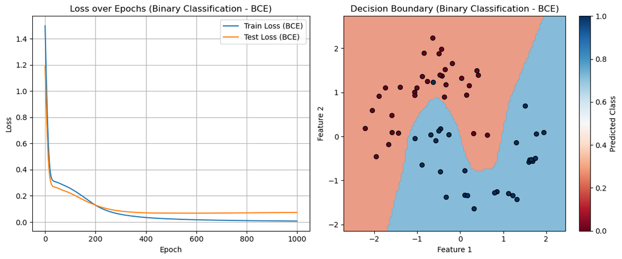

```python
# --- Example 1: Binary Classification with Binary Cross-Entropy ---
print("\n--- Binary Classification (make_moons) with BCE ---")

X_binary, y_binary = make_moons(n_samples=200, noise=0.15, random_state=42)
X_binary_train, X_binary_test, y_binary_train, y_binary_test = train_test_split(X_binary, y_binary, test_size=0.3, random_state=42)

scaler_b = StandardScaler()
X_binary_train_scaled = scaler_b.fit_transform(X_binary_train)
X_binary_test_scaled = scaler_b.transform(X_binary_test)

y_binary_train_reshaped = y_binary_train.reshape(-1, 1)
y_binary_test_reshaped = y_binary_test.reshape(-1, 1)

nn_bce = NeuralNetworkCE(input_size=X_binary_train_scaled.shape[1], hidden_size=50, output_size=1, output_activation='sigmoid')
epochs_bce = 1000
lr_bce = 0.005

train_losses_bce, test_losses_bce = train_nn(
    nn_bce, X_binary_train_scaled, y_binary_train_reshaped, X_binary_test_scaled, y_binary_test_reshaped,
    epochs_bce, lr_bce, 'bce'
)

plt.figure(figsize=(12, 5))
plt.subplot(1, 2, 1)
plt.plot(train_losses_bce, label='Train Loss (BCE)')
plt.plot(test_losses_bce, label='Test Loss (BCE)')
plt.title('Loss over Epochs (Binary Classification - BCE)')
plt.xlabel('Epoch')
plt.ylabel('Loss')
plt.legend()
plt.grid(True)

plt.subplot(1, 2, 2)
plot_decision_boundary(nn_bce, X_binary_test_scaled, y_binary_test_reshaped, 'Decision Boundary (Binary Classification - BCE)', is_binary=True)
plt.tight_layout()
plt.show()
```

2. **Multi-Class Classification with CCE (`make_blobs` dataset):**
   - **Data Preparation:** The `y_multi` (integer labels) are **one-hot encoded** into `y_multi_train_one_hot` and `y_multi_test_one_hot`. This is essential for CCE.
   - **Network Setup:** The `NeuralNetworkCE` is initialized with `output_activation='softmax'` and `output_size=num_classes`.
   - **Forward Pass:** The output layer uses `softmax` to convert the raw outputs (`Z2`) into a probability distribution over all classes. The sum of probabilities for each sample will be 1.
   - **Loss Calculation:** `categorical_cross_entropy_manual` is used.
   - **Backward Pass (`dL/dZ2`):** Similar to BCE with sigmoid, the derivative of Categorical Cross-Entropy combined with the Softmax activation function also simplifies beautifully to `(y_pred_probs - y_true_one_hot)`. This is why you rarely see separate softmax and CCE loss functions in libraries; they are almost always implemented as a single, numerically stable `softmax_cross_entropy_with_logits` (or similar) operation.
   - **Visualization:** The loss will decrease, and the decision boundary plot will show the network segmenting the space into regions corresponding to the different classes.

```
--- Multi-Class Classification (make_blobs) with CCE ---
Number of classes: 4
Epoch    0 | Train Loss: 1.6055 | Test Loss: 1.5282
Epoch  100 | Train Loss: 0.0126 | Test Loss: 0.0194
Epoch  200 | Train Loss: 0.0050 | Test Loss: 0.0135
Epoch  300 | Train Loss: 0.0028 | Test Loss: 0.0119
Epoch  400 | Train Loss: 0.0018 | Test Loss: 0.0113
Epoch  500 | Train Loss: 0.0012 | Test Loss: 0.0110
Epoch  600 | Train Loss: 0.0009 | Test Loss: 0.0108
Epoch  700 | Train Loss: 0.0007 | Test Loss: 0.0107
Epoch  800 | Train Loss: 0.0006 | Test Loss: 0.0106
Epoch  900 | Train Loss: 0.0005 | Test Loss: 0.0106
Final Test Accuracy: 0.9889
```

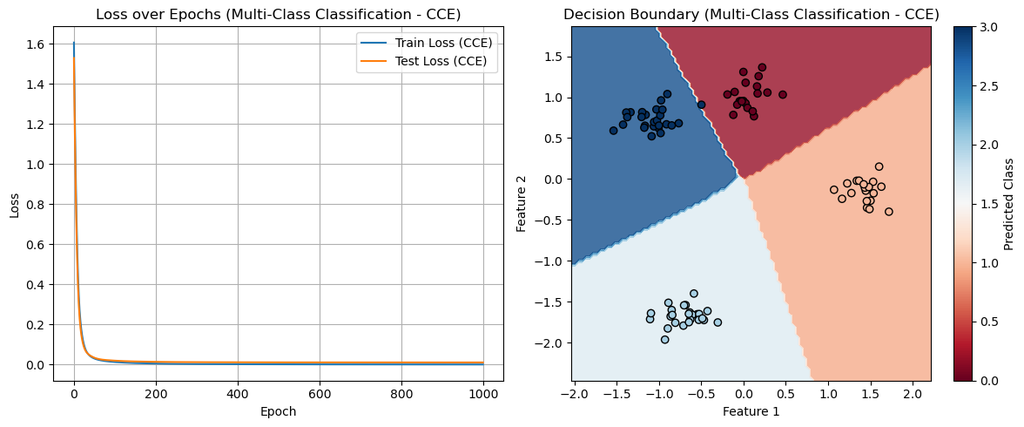

```python
# --- Example 2: Multi-Class Classification with Categorical Cross-Entropy ---
print("\n--- Multi-Class Classification (make_blobs) with CCE ---")

X_multi, y_multi = make_blobs(n_samples=300, centers=4, cluster_std=1.0, random_state=42)
X_multi_train, X_multi_test, y_multi_train, y_multi_test = train_test_split(X_multi, y_multi, test_size=0.3, random_state=42)

scaler_m = StandardScaler()
X_multi_train_scaled = scaler_m.fit_transform(X_multi_train)
X_multi_test_scaled = scaler_m.transform(X_multi_test)

# One-hot encode y for CCE
encoder = OneHotEncoder(sparse_output=False) # sparse=False for numpy array output
y_multi_train_one_hot = encoder.fit_transform(y_multi_train.reshape(-1, 1))
y_multi_test_one_hot = encoder.transform(y_multi_test.reshape(-1, 1))

num_classes = y_multi_train_one_hot.shape[1]
print(f"Number of classes: {num_classes}")

nn_cce = NeuralNetworkCE(input_size=X_multi_train_scaled.shape[1], hidden_size=50, output_size=num_classes, output_activation='softmax')
epochs_cce = 1000
lr_cce = 0.005

train_losses_cce, test_losses_cce = train_nn(
    nn_cce, X_multi_train_scaled, y_multi_train_one_hot, X_multi_test_scaled, y_multi_test_one_hot,
    epochs_cce, lr_cce, 'cce'
)

plt.figure(figsize=(12, 5))
plt.subplot(1, 2, 1)
plt.plot(train_losses_cce, label='Train Loss (CCE)')
plt.plot(test_losses_cce, label='Test Loss (CCE)')
plt.title('Loss over Epochs (Multi-Class Classification - CCE)')
plt.xlabel('Epoch')
plt.ylabel('Loss')
plt.legend()
plt.grid(True)

plt.subplot(1, 2, 2)
plot_decision_boundary(nn_cce, X_multi_test_scaled, y_multi_test_one_hot, 'Decision Boundary (Multi-Class Classification - CCE)', is_binary=False)
plt.tight_layout()
plt.show()
```

In summary, cross-entropy is the workhorse loss function for classification in neural networks.

Its various forms (BCE, CCE, SCCE) are chosen based on the number of classes and the encoding of target labels, but all serve the purpose of measuring the dissimilarity between predicted and true probability distributions, guiding the network to learn accurate classifications.